# K-mer Sequence Assembler

CS516 Bioinformatics - Project 2

Author

Israel Gonzalez S., Gabriel Romero

Published

February 27, 2023

# Abstract

In this project, we assemble input DNA k-mers to an output sequence, such that the assembled sequence has the same k-composition with the true unknown sequence. Also, it implements the de Bruijn graph to represent k-mers and then find a Eulerian path from the graph. For this, the project implements a hash function to match the prefix and suffix of a k-mer to those of other k-mers, implement de Bruijn graph construction to represent k-mers by a directed graph, and implement a Eulerian cycle finding algorithm to find a cycle on a directed graph.

# Introduction

Assembling genomes is a critical task in bioinformatics, as it allows researchers to study the genetic material of various organisms, including humans, animals, and plants. High-throughput sequencing technologies such as Illumina, Ion Torrent, and Pacific Biosciences generate massive amounts of short reads that need to be assembled into longer contiguous sequences (contigs). The de Bruijn graph approach is a widely used method for genome assembly that is based on constructing a graph where the nodes correspond to k-mers (substrings of length k) present in the reads, and the edges represent the overlaps between the k-mers. By traversing the graph using Eulerian cycles or paths, we can reconstruct the original sequence of the genome.

The advantage of using the de Bruijn graph approach is that it can handle large amounts of data efficiently and accurately, even for genomes with repetitive regions that are difficult to assemble using other methods. The approach also allows for the detection of genomic variations, such as single nucleotide polymorphisms (SNPs) and structural variations (SVs), by comparing the assembled genome to a reference genome or other assembled genomes.

Overall, the de Bruijn graph approach, coupled with the use of Eulerian cycles or paths, has revolutionized the field of genome assembly and has enabled researchers to study the genetics of a wide range of organisms with unprecedented accuracy and speed.

# Methods

We proceed in this section to describe the methods we have implemented in Python to emulate the skeleton code provided by Dr. Song, and the way they can be used in an executable Python file `main.py`

## Data structures and algorithms

```python
from test import test_seq_assembly

if __name__ == '__main__':
  test_seq_assembly()
```

This is the main file that calls the execution of tests.

```python
import sys
from timeit import default_timer as timer
from DiGraph import DiGraph
from sequence import random_DNA_sequence, get_kmers, compare_composition
from deBrujinByString import create_deBruijn_graph_by_string_comp
from deBrujinByHash import create_deBruijn_graph_by_hashing
from EulerPath import has_Eulerian_path, find_Eulerian_path
from k_assembler import build_sequence,assemble_kmers
import pandas as pd
import seaborn as sns
import matplotlib.pyplot as plt

def test_and_print_message(seq, seq_truth, k, message):
  if seq == seq_truth:
    msg = "Passed " + message + " (assembled original sequence). Congratulations!"
    print("\033[32m{}\033[0m".format(msg))
  elif compare_composition(seq, seq_truth, k):
    msg = "Passed " + message + " (assembled a sequence of the same composition with the original sequence). Congratulations!"
    print("\033[32m{}\033[0m".format(msg))
  else:
    sys.stderr.write("\033[31m{}\033[0m".format("FAILED test!\n"))

def test_1(method):
  print("\033[33m{}\033[0m".format("Test 1"))
  print("\033[33m{}\033[0m".format("======"))
  print(f"Testing k-assembler by {method}")

  # Testing sequences:
  seqs_truth = [
    "aaaaaaaaaaa",
    "agcagctcagc",
    "agcagctcagg",
    random_DNA_sequence(10000, 20000)
  ]

  # The value of k for k-mers to be used for each test sequence:
  ks = [5, 3, 3, 20]

  for i in range(len(seqs_truth)):
    print(f"\nExample {i}:")

    seq_truth = seqs_truth[i]
    k = ks[i]
    kmers = get_kmers(seq_truth, k, True)
    g = DiGraph()

    begin = timer()
    if method == "k-mer pairwise comparison":
      g = create_deBruijn_graph_by_string_comp(kmers, g)
    elif method == "k-mer hashing":
      g = create_deBruijn_graph_by_hashing(kmers, g)
    else:
      sys.stderr.write("ERROR: unknown method!\n")
      return
    end = timer()
    elapsed_secs = round((end - begin) * 1000, 3)

    print(f"Elapsed time for building de Bruijn graph: {elapsed_secs}")

    if has_Eulerian_path(g):
      print("\033[32m{}\033[0m".format("Passed test for existence of Eulerian path. Congratulations!"))
    else:
      print("\033[31m{}\033[0m".format("Failed test for existence of Eulerian path!"))

    try:
      path = find_Eulerian_path(g)
      seq = build_sequence(path, g)
      message = f"Test 1 Example {i}"
      test_and_print_message(seq, seq_truth, k, message)
    except Exception as e:
      sys.stderr.write(f"ERROR: {e}\n")
      return


def test_2(method):
  print("\033[33m{}\033[0m".format("Test 2"))
  print("\033[33m{}\033[0m".format("======"))
  seq_truth = random_DNA_sequence()
  k = 10
  kmers = get_kmers(seq_truth, k)
  try:
      seq = assemble_kmers(kmers, method)
      test_and_print_message(seq, seq_truth, k, "Test 2")
  except Exception as e:
      print(e)

def test_3(method):
  print("\033[33m{}\033[0m".format("Test 3"))
  print("\033[33m{}\033[0m".format("======"))
  seq_truth = random_DNA_sequence(15, 15)
  k = 4
  print("Sequence:", seq_truth)
  kmers = get_kmers(seq_truth, k)
  print("kmers:")
  for kmer in kmers:
      print(kmer)
  try:
      seq = assemble_kmers(kmers, method, "deBruijn.dot")
      test_and_print_message(seq, seq_truth, k, "Test 3")
  except Exception as e:
      print(e)

def generate_chart(method):
  print()
  print("\033[33m{}\033[0m".format("Output for report"))
  print("\033[33m{}\033[0m".format("=================="))
  ks = [3, 5, 7, 9, 11, 13, 15, 17, 19]
  seqs_truth = [
    random_DNA_sequence(100, 500),
    random_DNA_sequence(100, 1000),
    random_DNA_sequence(1000, 2000),
    random_DNA_sequence(1000, 3000),
    random_DNA_sequence(1000, 4000),
    random_DNA_sequence(1000, 5000),
    random_DNA_sequence(1000, 6000),
    random_DNA_sequence(1000, 7000),
    random_DNA_sequence(1000, 8000)
  ]

  run_times = []
  for i in range(len(seqs_truth)):
    seq_truth = seqs_truth[i]
    k = ks[i]
    kmers = get_kmers(seq_truth, k, True)
    g = DiGraph()
    begin = timer()
    if method == "k-mer pairwise comparison":
      g = create_deBruijn_graph_by_string_comp(kmers, g)
    elif method == "k-mer hashing":
      g = create_deBruijn_graph_by_hashing(kmers, g)
    else:
      sys.stderr.write("ERROR: unknown method!\n")
      return
    end = timer()
    elapsed_secs = round((end - begin) * 1000, 3)
    run_times.append(elapsed_secs)

  data = {'k':ks,'run_time':run_times}
  df = pd.DataFrame(data)
  sns.lineplot(data=df, x='k', y='run_time')
  plt.xlabel('K')
  plt.ylabel('Run Time (secs)')
  plt.title('Method: ' + method.upper())
  png_file_name = method.lower().replace(" ", "-")
  plt.savefig("../docs/images/" + png_file_name + '.png')
  print("Report plots have been generated in /docs/images folder...\n")

  print("|Language|Method|K-length|Run time (secs)|")
  print("|:----:|:----:|:---:|:-----:|")
  for i in range(0,len(ks)):
    print("|Python|",method,"|",ks[i],"|",run_times[i])


def test_seq_assembly():
  methods = [
    "k-mer pairwise comparison",
    "k-mer hashing"
  ]
  for method in methods:
    print()
    test_1(method)
    print()
    test_2(method)
    print()
  test_3("k-mer hashing")

  for method in methods:
    generate_chart(method)
```

We have stated in this block the tests because they are a translation of what we had in the C++ skeleton for this project. We have added a function to plot a chart where we show the run time comparison between methods, and also its detail in tables.

```python
from pyllist import dllist

class Node:

  def __init__(self, label: str):
    self.m_label = label
    self.m_outgoing = dllist()
    self.m_num_of_incoming = 0

  def print(self):
    print("  ",self.m_label)
    print("   incoming: ",str(self.m_num_of_incoming))
    print("     edges: ",self.m_outgoing)

class DiGraph:

  def __init__(self):
    self.m_nodes = []

  def print(self):
    print("---------------------------------------")
    print(" DiGraph ", len(self.m_nodes), " nodes")
    for node in self.m_nodes:
      node.print()
    print("---------------------------------------")

  def textRepresentation(self, hide_labels = True):
    answer = ""
    for i in range(0, len(self.m_nodes)):
      node = self.m_nodes[i]
      if hide_labels:
        answer += str(i) + ' -> '
      else:
        answer += str(i) + '(' + node.m_label + ')' + ' -> '
      elems = list(node.m_outgoing)
      edges = []
      for elem in elems:
        if elem is not None:
          edges.append(str(elem))
      answer += ','.join(edges)
      answer += '\n'
    return answer
```

As task 2 in this project requires, these classes, DiGraph and Node together, implement a de Bruijn graph to represent k-mers and its relationships by a directed graph. In our case, we decided to use a double linked list (dllist) to represent the secuence of edges from a node. This decision was good not only in terms of run time efficiency but also sometimes since, for example, in the construction of the Eulerian path we could traverse bothways. Also, we have added auxiliary methods to print the information or to represent the graph in its classi text representation. These classes are stable.

```python
from typing import List
from pyllist import dllist
from DiGraph import DiGraph, Node

def create_deBruijn_graph_by_string_comp(kmers: List[str], g: DiGraph):

  nodes = dllist()

  for kmer in kmers:
    k = len(kmer)

    prefix = kmer[0:k-1]

    itr = nodes.first
    i = 0
    while itr is not None:
      if itr.value.m_label == prefix:
        break
      itr = itr.next
      i += 1

    if itr is None:
      from_node = Node(prefix)
      from_node.m_num_of_incoming = 0
      nodes.append(from_node)
      itr = nodes.last

    from_itr = itr

    suffix = kmer[1:k]

    itr = nodes.first
    j = 0
    while itr is not None:
      if itr.value.m_label == suffix:
        break
      itr = itr.next
      j += 1

    if itr is None:
      to_node = Node(suffix)
      to_node.m_num_of_incoming = 0

      nodes.append(to_node)

      itr = nodes.last

    to_itr = itr

    from_itr.value.m_outgoing.append(j)
    to_itr.value.m_num_of_incoming += 1

  g.m_nodes = [node for node in nodes]
  return g
```

This is the translation we have produced in Python for the explicit function to create the de Brujin graph by k-mer string pairwise comparison. As we wil see later, this function has a quadratic behavior in terms of run time. This function is stable.

```python
class DNAHasher:
  def __call__(self, seq: str) -> int:
    val = 0
    max_width = 20
    for i in range(min(len(seq), max_width)):
      val = val << 2
      c = seq[i].lower()
      if c == 'a':
        val += 0
      elif c == 'c':
        val += 1
      elif c == 'g':
        val += 2
      elif c == 't':
        val += 3
      else:
        raise ValueError(f"Invalid base at position {i}: {seq[i]}")
    return val

class CSeqHash:
    def __init__(self):
        self.ht = defaultdict(dllist)

    def insert(self, key, value):
        self.ht[key].appendright(value)

    def find(self, key):
        return self.ht.get(key, None)

def create_hash_table(kmers: List[str]) -> CSeqHash:
    ht = CSeqHash()
    node_id = 0
    for kmer in kmers:
        for j in range(2):  # j=0: prefix; j=1: suffix
            key = kmer[j:len(kmer)-1]
            if not ht.find(key):
                ht.insert(key, node_id)
                node_id += 1
    return ht

def create_deBruijn_graph_by_hashing(kmers: List[str], g: DiGraph):

    seq_hash = CSeqHash()

    node_id = {}

    # for each k-mer
    for kmer in kmers:
        kmer_len = len(kmer)
        prefix = kmer[0:kmer_len-1]
        suffix = kmer[1:kmer_len]

        # hash the prefix and suffix strings to get unique integer ids
        prefix_id = DNAHasher()(prefix)
        suffix_id = DNAHasher()(suffix)

        # find the prefix node id from the hash table
        if prefix_id in node_id:
            from_id = node_id[prefix_id]
        else:
            # create a new node and add it to the graph and node_id dict
            from_node = Node(prefix)
            g.m_nodes.append(from_node)
            node_id[prefix_id] = len(g.m_nodes) - 1
            from_id = node_id[prefix_id]
            # insert the new node into the hash table
            seq_hash.insert(prefix_id, from_id)

        # update node from_id's label to prefix if necessary
        if g.m_nodes[from_id].m_label != prefix:
            g.m_nodes[from_id].m_label = prefix

        # find the suffix node id to_id from the hash table
        if suffix_id in node_id:
            to_id = node_id[suffix_id]
        else:
            # create a new node and add it to the graph and node_id dict
            to_node = Node(suffix)
            g.m_nodes.append(to_node)
            node_id[suffix_id] = len(g.m_nodes) - 1
            to_id = node_id[suffix_id]
            # insert the new node into the hash table
            seq_hash.insert(suffix_id, to_id)

        # update node to_id's label to suffix if necessary
        if g.m_nodes[to_id].m_label != suffix:
            g.m_nodes[to_id].m_label = suffix

        # create a new edge (from_id, to_id) by inserting node to_id into the adjaceny list of node from_id
        g.m_nodes[from_id].m_outgoing.appendright(to_id)

        # update the number of incoming edges of node to_id
        g.m_nodes[to_id].m_num_of_incoming += 1

    # end for loop
    return g
```

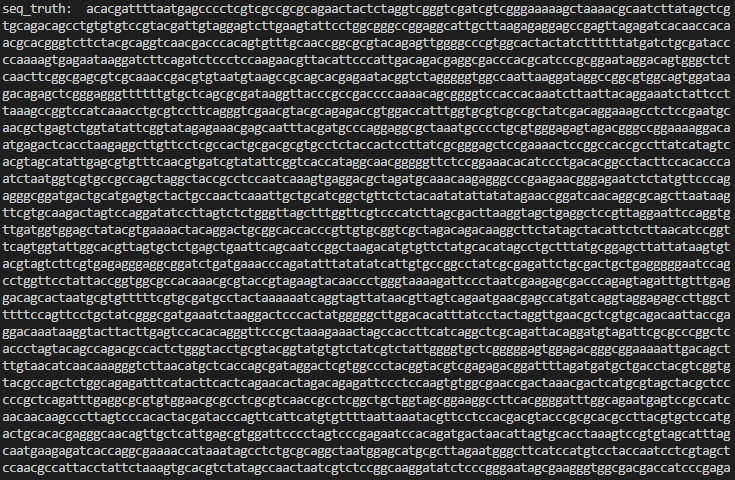

Also, we have programmed the create_deBruijn_graph_by_hashing that basically receiving the graph and the list of kmers using appropiate the keys, produces hashes (generating the hash the prefix and suffix strings to get unique integer ids) so that the execution of the creation of the de Brujin graph is in linear time. These functions are stable.

```python
from random import randint
from copy import deepcopy

def CreateAdjacencyList2(g_text_rep):

    adj_list = {}
    circuit_max = 0
    lines = [line.strip() for line in g_text_rep.splitlines()]
    for line in lines:
        node = line.strip('\n')
        node = node.replace(' -> ', ' ')
        node = node.split(' ')
        adj_list.setdefault(node[0], [])
        for number in node[1].split(','):
            adj_list[node[0]].append(number)
            circuit_max += 1

    return adj_list, circuit_max


def FindEulerianCycle(adj_list, circuit_max):

    #Reduced adjacency list to keep track of traveled edges
    red_adj_list = {}
    red_adj_list = deepcopy(adj_list)

    #Arbitrary starting point (if graph is directed/balanced)
    start = '0'
    curr_vrtx = '0'

    stack = []
    circuit = []
    while len(circuit) != circuit_max:

        if red_adj_list[curr_vrtx] != []: #If neighbors exist
            stack.append(curr_vrtx)
            pick = randint(0,len(red_adj_list[curr_vrtx])-1)
            temp = deepcopy(curr_vrtx)
            curr_vrtx = red_adj_list[temp][pick]
            red_adj_list[temp].remove(curr_vrtx)

        else:
            circuit.append(curr_vrtx)
            curr_vrtx = stack[len(stack)-1]
            stack.pop()

    #Formatting
    path_array = [int(start)]
    path = start + '->'
    for vrtx in circuit[::-1]:
        path += (vrtx + '->')
        path_array.append(int(vrtx))

    return path_array
```

After testing many strategies spending many days of effort, this is our last implementation of a class that produces an Eulerian Cycle based on an adjacency list to work only with nodes ids (not labels). It does it job great part of the time but it has a known issue we will explain later.

```python
from collections import defaultdict
from typing import List
from pyllist import dllist
from DiGraph import DiGraph, Node
from random import choice
from EulerianCycle import CreateAdjacencyList2, FindEulerianCycle

def source(g:DiGraph):
  for i, node in enumerate(g.m_nodes):
    if len(node.m_outgoing) == node.m_num_of_incoming + 1:
      return i
  return 0

def sink(g:DiGraph):
  for i, node in enumerate(g.m_nodes):
    if len(node.m_outgoing) + 1 == node.m_num_of_incoming:
      return i
  return 0

def has_Eulerian_path(g:DiGraph):
  exist = True
  numSources, numSinks = 0, 0
  for node in g.m_nodes:
    out, incoming = len(node.m_outgoing), node.m_num_of_incoming
    if out == incoming: # check for intermediate balanced node
      continue
    elif out == incoming + 1: # check for source node
      numSources += 1
      if numSources > 1:
        exist = False
        break
    elif out + 1 == incoming: # check for sink node
      numSinks += 1
      if numSinks > 1:
        exist = False
        break
    else:
      exist = False
      break
  return exist

def find_Eulerian_cycle(g: DiGraph) -> dllist:
    cycle_labels, cycle_values = dllist(), dllist()
    adj_list, circuit_max = CreateAdjacencyList2(g.textRepresentation())
    path = FindEulerianCycle(adj_list, circuit_max)
    for index in path:
      cycle_labels.append(g.m_nodes[index].m_label)
      cycle_values.append(index)
    return cycle_labels, cycle_values


def find_Eulerian_path(g: DiGraph) -> dllist:
  path, cycle = dllist(), dllist()

  src = source(g)
  dest = sink(g)
  src = 0 if src >= len(g.m_nodes) else src
  dest = 0 if dest >= len(g.m_nodes) else dest

  nodes = g.m_nodes
  nodes[dest].m_outgoing.append(src)
  nodes[src].m_num_of_incoming += 1
  g.m_nodes = nodes

  cycle_labels, cycle = find_Eulerian_cycle(g)
  cycle.pop()
  cycle_labels.pop()

  src_times = 0
  for id in cycle:
    if id == src:
      src_times += 1

  first_part = []
  count = 1
  cur_first_part = cycle.first
  while cur_first_part.next is not None:
    if count == src_times and cur_first_part.value == src:
      break
    if cur_first_part.value == src:
      count += 1
    first_part.append(cur_first_part.value)
    cur_first_part = cur_first_part.next

  cur_last_part = cycle.last
  last_part = []
  while cur_last_part.value != src:
    last_part.append(cur_last_part.value)
    cur_last_part = cur_last_part.prev

  path_ids = [src]
  if last_part is not None:
    path_ids += last_part[::-1]
  if first_part is not None:
    path_ids += first_part

  path = dllist()
  if len(path_ids) > 0:
    for id in path_ids:
      path.append(g.m_nodes[id].m_label)
  else:
    path.append(src)

  return path
```

Here, there are the functions to detect the presence of a Eulerian cycle given an Eulerian Cycle, and based on our representation of the de Brujing directed graph, produces a Eulerian path. The behavior of these functions are stable.

```python
from typing import List
from pyllist import dllist
from DiGraph import DiGraph, Node
from deBrujinByString import create_deBruijn_graph_by_string_comp
from deBrujinByHash import create_deBruijn_graph_by_hashing
from EulerPath import has_Eulerian_path, find_Eulerian_path

def dllist_index(my_list, elem):
    index = 0
    current_node = my_list.first
    while current_node is not None:
        if current_node.value == elem:
            break
        current_node = current_node.next
        index += 1
    return index

def build_sequence(path: dllist, g: DiGraph) -> str:
    k = len(path.first.value) + 1
    seq = path.first.value[:k-1]
    pos = path.first.next
    while pos != path.last:
        seq += pos.value[-1]
        pos = pos.next
    seq += path.last.value[-1]
    return seq

def assemble_kmers(kmers, method, dotfile=None):
    seq = ""
    g = DiGraph()
    if method == "k-mer pairwise comparison":
        create_deBruijn_graph_by_string_comp(kmers, g)
    elif method == "k-mer hashing":
        create_deBruijn_graph_by_hashing(kmers, g)
    else:
        raise ValueError("ERROR: unknown methods!")
    if dotfile:
        printDOTFile(g, dotfile)
    if not has_Eulerian_path(g):
        raise ValueError("ERROR: Eulerian path does not exist!")
    else:
        path = find_Eulerian_path(g)
        seq = build_sequence(path, g)
    return seq

def printDOTFile(g, file):
    with open(file, 'w') as ofs:
        ofs.write("digraph {\n")
        ofs.write("label=\"de Bruijn graph\"\n")
        nodes = g.m_nodes
        for node in nodes:
            for to in node.m_outgoing:
                prefix = node.m_label
                suffix = nodes[to].m_label
                ofs.write(f"{prefix}->{suffix}[label={prefix}{suffix[-1]}];\n")
        ofs.write("}\n")
```

Here we have programmed in Python the functions the skeleton offers to finally build the sequence and assemble kmers. Also, the function to generate the deBrujin.dot persistence file. These functions are stable.

```python
import random

def random_DNA_sequence(min_length=10, max_length=10000):
  length = random.randint(min_length, max_length)
  DNA = ''.join(random.choice('atgc') for _ in range(length))
  return DNA

def get_kmers(seq, k, randomized=True):
  kmers = [seq[i:i+k] for i in range(len(seq) - k + 1)]
  if randomized:
    randomized_kmers = list(kmers)
    nkmers = len(kmers)
    for i in range(nkmers - 1):
      j = random.randint(i, nkmers - 1)
      randomized_kmers[i], randomized_kmers[j] = randomized_kmers[j], randomized_kmers[i]
    return randomized_kmers
  else:
    return kmers

def compare_composition(s1: str, s2: str, k: int) -> bool:
  same_composition = True

  if len(s1) != len(s2):
    same_composition = False
  elif s1 == s2:
    same_composition = True
  else:
    composition1 = get_kmers(s1, k)
    composition1.sort()
    composition2 = get_kmers(s2, k)
    composition2.sort()
    same_composition = composition1 == composition2

  return same_composition
```

Finally, we state in our project the functions to generate the random DNA sequence, get kmers given a sequence and a length for k, and the function that inspects if two kmers have the same composition. These functions are stable.

## How to compile and run project’s code

### Python

To run the `main.py` program correctly. the following are the steps are required

- Unzip this project on a path where Python 3.8 or superior is active
- Open a console and go to where the unzipped folder is. Make sure you are in the same level where the `main.py` program is. You can be sure of this printing the directory content with `ls` command
- Run the program with the command `py main.py`
- The program will produce a similar output we have in this report, and also plots, and tables the following sections has in its analysis.

# Results

## Screenshot of the required test cases

This is an example of execution of our main program:

```
PS C:\Development\nmsu\nmsu-cs516-bioinformatics-project\ps02\python> py .\main.py

Test 1
======
Testing k-assembler by k-mer pairwise comparison

Example 0:
Elapsed time for building de Bruijn graph: 0.026
Passed test for existence of Eulerian path. Congratulations!
Passed Test 1 Example 0 (assembled original sequence). Congratulations!

Example 1:
Elapsed time for building de Bruijn graph: 0.033
Passed test for existence of Eulerian path. Congratulations!
Passed Test 1 Example 1 (assembled a sequence of the same composition with the original sequence). Congratulations!

Example 2:
Elapsed time for building de Bruijn graph: 0.043
Passed test for existence of Eulerian path. Congratulations!
Passed Test 1 Example 2 (assembled a sequence of the same composition with the original sequence). Congratulations!

Example 3:
Elapsed time for building de Bruijn graph: 47749.686
Passed test for existence of Eulerian path. Congratulations!
Passed Test 1 Example 3 (assembled original sequence). Congratulations!

Test 2
======
Passed Test 2 (assembled a sequence of the same composition with the original sequence). Congratulations!


Test 1
======
Testing k-assembler by k-mer hashing

Example 0:
Elapsed time for building de Bruijn graph: 0.065
Passed test for existence of Eulerian path. Congratulations!
Passed Test 1 Example 0 (assembled original sequence). Congratulations!

```

[output cut: 21 more lines]

```
Sequence: caagcatggtatgcg
kmers:
gcat
atgc
atgg
aagc
agca
tatg
tgcg
gtat
catg
caag
ggta
tggt
Passed Test 3 (assembled original sequence). Congratulations!
```

Important note: This execution is flawless. The current version (Tue 28 mar) makes a good but a not a perfect job. Having fixed some important issues to get this level of results now, there is a last issue finding a correct Eulerian Cyle when there are repetitions of nodes. In that case, not always produce a good cycle. In future version, we should fix that issue.

## The k-assembler run time as a function of the number of k-mers

### Results for k-assembler by k-mer pairwise comparison

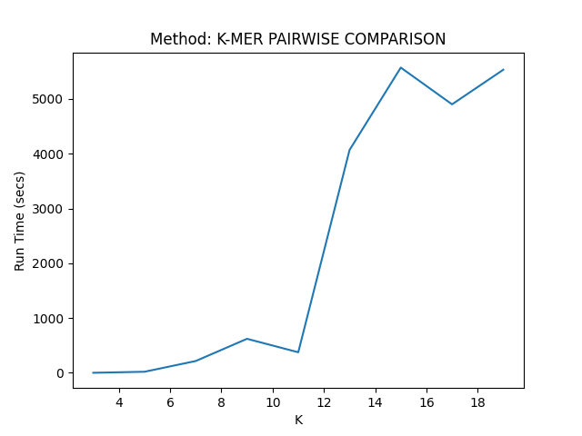

Figure 2: Run time of kmer hassembler by pairwise comparison

In this chart, we clearly see that the run time is considerable when we use this method to assemble. The evolution has a quadratic pattern.

[output not shown]

### Results for k-assembler by k-mer hashing

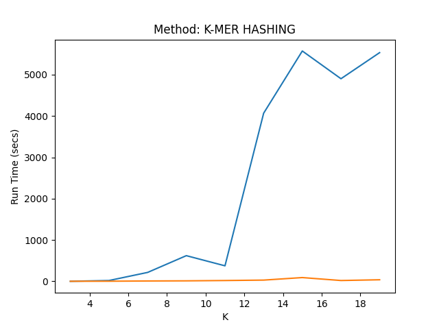

Figure 3: Run time of kmer assembler by hashing

In this chart, we clearly see that the run time is much less when we use this method to assemble. The evolution has a linear pattern (orange line). Also, to compare the proportions, we have put also the previous method so that we can appreciate the efficiency this algorithm brings.

[output not shown]

# Discussion

As last words, we can say that this project was intense for us. It required more effort since we decided to follow the skeleton in C++ but translating it to Python. Then, we run the extra mile in that sense. However, it was a great experience and we are grateful for having had it as part of our academic formation.

# Distribution of work among team members

Israel Gonzalez:

- Complete translation of C++ skeleton into Python
- Development of required solution
- Visualization of run time versus the number of k-mers using Seaborn
- Report writing

Gabriel Romero:

- Compilation and run in C++ of skeleton